# Homework 07

## Question 1: LDA

```python
heart = pd.read_csv("data/saheart.csv")
heart["famhist"] = heart["famhist"].map({"Absent": 1, "Present": 2})
predictor_names = heart.columns.drop("chd")
X = heart[predictor_names].to_numpy(dtype=float)
y = heart["chd"].to_numpy()
classes = np.unique(y)
n, p = X.shape

priors = np.array([(y == k).mean() for k in classes])
means = np.vstack([X[y == k].mean(axis=0) for k in classes])
pooled_cov = sum(
    (X[y == k] - means[i]).T @ (X[y == k] - means[i])
    for i, k in enumerate(classes)
) / (n - len(classes))

print("n =", n, ", p =", p)
display(pd.Series(priors, index=classes, name="prior").to_frame())
display(pd.DataFrame(means, index=classes, columns=predictor_names))
display(pd.DataFrame(pooled_cov, index=predictor_names, columns=predictor_names))
```

```
n = 462 , p = 9
```

|  | prior |
| --- | --- |
| 0 | 0.6537 |
| 1 | 0.3463 |

|  | sbp | tobacco | ldl | adiposity | famhist | typea | obesity | alcohol | age |
| --- | --- | --- | --- | --- | --- | --- | --- | --- | --- |
| 0 | 135.4603 | 2.6347 | 4.3442 | 23.9691 | 1.3179 | 52.3675 | 25.7375 | 15.9314 | 38.8543 |
| 1 | 143.7375 | 5.5249 | 5.4879 | 28.1202 | 1.6000 | 54.4937 | 26.6229 | 19.1452 | 50.2938 |

|  | sbp | tobacco | ldl | adiposity | famhist | typea | obesity | alcohol | age |
| --- | --- | --- | --- | --- | --- | --- | --- | --- | --- |
| sbp | 405.4348 | 14.5852 | 4.5812 | 49.1644 | 0.3370 | -15.5877 | 18.9388 | 64.4004 | 95.1339 |
| tobacco | 14.5852 | 19.2426 | 0.7632 | 7.5381 | 0.0158 | -2.0573 | 1.8335 | 20.5170 | 22.7654 |
| ldl | 4.5812 | 0.7632 | 4.0006 | 6.0327 | 0.0919 | 0.3446 | 2.6601 | -2.5329 | 6.4789 |
| adiposity | 49.1644 | 7.5381 | 6.0327 | 56.7529 | 0.4328 | -5.3096 | 22.7079 | 16.1190 | 60.5087 |
| famhist | 0.3370 | 0.0158 | 0.0919 | 0.4328 | 0.2258 | 0.0811 | 0.1840 | 0.7685 | 0.9974 |
| typea | -15.5877 | -2.0573 | 0.3446 | -5.3096 | 0.0811 | 95.5656 | 2.6401 | 7.9600 | -20.2783 |
| obesity | 18.9388 | 1.8335 | 2.6601 | 22.7079 | 0.1840 | 2.6401 | 17.6154 | 4.6894 | 15.6970 |
| alcohol | 64.4004 | 20.5170 | -2.5329 | 16.1190 | 0.7685 | 7.9600 | 4.6894 | 598.2766 | 27.8859 |
| age | 95.1339 | 22.7654 | 6.4789 | 60.5087 | 0.9974 | -20.2783 | 15.6970 | 27.8859 | 184.1321 |

### (a) Estimated components

The empirical prior probabilities are $\hat\pi_0=0.6537$ and $\hat\pi_1=0.3463$. The class means and pooled covariance matrix above use all nine numerical predictors, with `famhist` coded as requested. I computed

$$\widehat\Sigma=\frac{1}{n-K}\sum_{k=0}^1
\sum_{i:y_i=k}(x_i-\widehat\mu_k)(x_i-\widehat\mu_k)^\mathsf{T},$$

so its denominator is $462-2=460$.

### (b) Scores calculated directly

```python
inv_cov = np.linalg.inv(pooled_cov)
scores = np.column_stack([
    X @ inv_cov @ means[i]
    - 0.5 * means[i] @ inv_cov @ means[i]
    + np.log(priors[i])
    for i in range(len(classes))
])
pred_manual = classes[np.argmax(scores, axis=1)]
cm_manual = confusion_matrix(y, pred_manual, labels=classes)

print("X:", X.shape, "means:", means.shape,
      "covariance:", pooled_cov.shape, "scores:", scores.shape)
display(pd.DataFrame(cm_manual,
                     index=["observed 0", "observed 1"],
                     columns=["predicted 0", "predicted 1"]))
```

```
X: (462, 9) means: (2, 9) covariance: (9, 9) scores: (462, 2)
```

|  | predicted 0 | predicted 1 |
| --- | --- | --- |
| observed 0 | 258 | 44 |
| observed 1 | 73 | 87 |

The dimensions are compatible: $X$ is $462\times9$, the two means form a $2\times9$ matrix, the covariance matrix is $9\times9$, and the score matrix is $462\times2$. The in-sample error rate is $(44+73)/462=0.2532$.

### (c) `LinearDiscriminantAnalysis`

```python
lda = LinearDiscriminantAnalysis(solver="svd", priors=priors).fit(X, y)
pred_sklearn = lda.predict(X)
cm_sklearn = confusion_matrix(y, pred_sklearn, labels=classes)
display(pd.DataFrame(cm_sklearn,
                     index=["observed 0", "observed 1"],
                     columns=["predicted 0", "predicted 1"]))
print("All fitted labels match:", np.array_equal(pred_manual, pred_sklearn))
```

|  | predicted 0 | predicted 1 |
| --- | --- | --- |
| observed 0 | 258 | 44 |
| observed 1 | 73 | 87 |

```
All fitted labels match: True
```

The confusion matrices and every fitted label match. This is expected because both calculations use empirical priors, class means, and the same shared within-class covariance information; the SVD solver obtains the discriminant rule without explicitly inverting the covariance matrix.

## Question 2: QDA and marginal screening

```python
zip_train = pd.read_csv("data/zip-train.csv.gz", header=None).to_numpy()
zip_test = pd.read_csv("data/zip-test.csv.gz", header=None).to_numpy()
y_train = zip_train[:, 0].astype(int)
X_train = zip_train[:, 1:]
y_test = zip_test[:, 0].astype(int)
X_test = zip_test[:, 1:]

# Selection uses only training data. A stable sort makes ties reproducible.
pixel_variances = X_train.var(axis=0, ddof=1)
variance_order = np.argsort(-pixel_variances, kind="stable")

q2_results = {}
for d in (40, 10):
    selected = variance_order[:d]
    model = QuadraticDiscriminantAnalysis(tol=1e-8)
    with warnings.catch_warnings(record=True) as caught:
        warnings.simplefilter("always")
        model.fit(X_train[:, selected], y_train)
        pred = model.predict(X_test[:, selected])
    ranks = [
        np.linalg.matrix_rank(
            np.cov(X_train[y_train == k][:, selected], rowvar=False)
        )
        for k in range(10)
    ]
    q2_results[d] = {
        "selected": selected,
        "confusion": confusion_matrix(y_test, pred, labels=np.arange(10)),
        "error": np.mean(pred != y_test),
        "ranks": ranks,
        "warnings": sorted({str(w.message) for w in caught}),
    }
```

### (a) Forty predictors

```python
r40 = q2_results[40]
display(pd.DataFrame(r40["confusion"], index=np.arange(10), columns=np.arange(10))
        .rename_axis("observed").rename_axis("predicted", axis=1))
print(f"Test misclassification rate: {r40['error']:.4f}")
print("Within-class covariance ranks:", r40["ranks"])
print("Numerical warnings:", r40["warnings"] or "none")
```

| predicted observed | 0 | 1 | 2 | 3 | 4 | 5 | 6 | 7 | 8 | 9 |
| --- | --- | --- | --- | --- | --- | --- | --- | --- | --- | --- |
| 0 | 319 | 0 | 24 | 6 | 2 | 2 | 1 | 0 | 5 | 0 |
| 1 | 0 | 238 | 5 | 0 | 11 | 0 | 7 | 0 | 3 | 0 |
| 2 | 8 | 0 | 168 | 8 | 8 | 3 | 0 | 0 | 3 | 0 |
| 3 | 5 | 0 | 4 | 128 | 0 | 14 | 0 | 0 | 15 | 0 |
| 4 | 0 | 2 | 13 | 1 | 150 | 1 | 0 | 1 | 7 | 25 |
| 5 | 12 | 0 | 3 | 5 | 1 | 131 | 0 | 0 | 6 | 2 |
| 6 | 0 | 0 | 8 | 0 | 1 | 8 | 148 | 0 | 5 | 0 |
| 7 | 1 | 0 | 6 | 1 | 6 | 0 | 0 | 124 | 2 | 7 |
| 8 | 1 | 0 | 10 | 12 | 3 | 2 | 0 | 0 | 137 | 1 |
| 9 | 0 | 0 | 1 | 2 | 7 | 1 | 1 | 4 | 9 | 152 |

```
Test misclassification rate: 0.1555
Within-class covariance ranks: [np.int64(40), np.int64(40), np.int64(40), np.int64(40), np.int64(40), np.int64(40), np.int64(40), np.int64(40), np.int64(40), np.int64(40)]
Numerical warnings: none
```

The test misclassification rate is **0.1555** (312 errors among 2,007 test digits).

### (b) Does it work?

Yes. All ten estimated $40\times40$ within-class covariance matrices have full rank 40, and the fit produced no collinearity warning. Marginal screening removes many nearly constant or redundant pixels, leaving far fewer covariance parameters per class than the original 256-pixel analysis. Each digit class also has many more than 40 training observations, so its covariance matrix can be estimated. The remaining 15.55% error shows that large marginal variance is useful but not the same as maximal class discrimination.

### (c) Ten predictors

```python
r10 = q2_results[10]
display(pd.DataFrame(r10["confusion"], index=np.arange(10), columns=np.arange(10))
        .rename_axis("observed").rename_axis("predicted", axis=1))
print(f"Test misclassification rate: {r10['error']:.4f}")
print(f"Increase relative to 40 predictors: {r10['error'] - r40['error']:.4f}")
```

| predicted observed | 0 | 1 | 2 | 3 | 4 | 5 | 6 | 7 | 8 | 9 |
| --- | --- | --- | --- | --- | --- | --- | --- | --- | --- | --- |
| 0 | 298 | 0 | 11 | 1 | 1 | 16 | 28 | 4 | 0 | 0 |
| 1 | 0 | 241 | 10 | 0 | 3 | 1 | 1 | 0 | 2 | 6 |
| 2 | 19 | 2 | 95 | 14 | 14 | 3 | 22 | 21 | 5 | 3 |
| 3 | 5 | 0 | 6 | 103 | 3 | 42 | 0 | 0 | 7 | 0 |
| 4 | 1 | 5 | 14 | 0 | 95 | 2 | 4 | 15 | 17 | 47 |
| 5 | 15 | 0 | 6 | 25 | 4 | 96 | 4 | 2 | 8 | 0 |
| 6 | 41 | 0 | 15 | 4 | 0 | 18 | 78 | 7 | 5 | 2 |
| 7 | 4 | 1 | 6 | 0 | 6 | 0 | 1 | 122 | 0 | 7 |
| 8 | 1 | 2 | 11 | 36 | 12 | 11 | 4 | 1 | 74 | 14 |
| 9 | 0 | 2 | 9 | 2 | 20 | 0 | 0 | 16 | 10 | 118 |

```
Test misclassification rate: 0.3423
Increase relative to 40 predictors: 0.1868
```

The 10-predictor error is **0.3423**, an increase of 0.1868 (18.68 percentage points). Reducing dimension makes each class covariance easier to estimate, but here that variance reduction is overwhelmed by bias and information loss: ten high-variance pixels do not preserve enough of each digit’s shape. The 40-predictor model strikes a much better balance.

## Question 3: Compare LDA and QDA

I used seed **43207**. For each $\rho$, both classifiers receive exactly the same 200 training observations and 2,000 test observations.

```python
def generate_sample(rho, rng, n_per_class):
    cov1 = np.eye(10)
    cov2 = np.eye(10)
    cov1[0, 1] = cov1[1, 0] = rho
    cov2[0, 1] = cov2[1, 0] = -rho
    mu1 = np.zeros(10); mu1[0] = -1
    mu2 = np.zeros(10); mu2[0] = 1
    x1 = rng.multivariate_normal(mu1, cov1, size=n_per_class)
    x2 = rng.multivariate_normal(mu2, cov2, size=n_per_class)
    return (np.vstack([x1, x2]),
            np.r_[np.ones(n_per_class, dtype=int),
                  np.full(n_per_class, 2, dtype=int)])

def run_once(rho, rng):
    Xtr, ytr = generate_sample(rho, rng, 100)
    Xte, yte = generate_sample(rho, rng, 1000)
    lda = LinearDiscriminantAnalysis(solver="svd", priors=[.5, .5]).fit(Xtr, ytr)
    qda = QuadraticDiscriminantAnalysis(priors=[.5, .5], tol=1e-8).fit(Xtr, ytr)
    return (np.mean(lda.predict(Xte) != yte),
            np.mean(qda.predict(Xte) != yte))

rhos = np.array([0, .2, .4, .6, .8, .9])
```

### (a) One dataset per value of $\rho$

```python
rng = np.random.default_rng(SEED)
single_errors = np.array([run_once(rho, rng) for rho in rhos])
display(pd.DataFrame(single_errors, index=rhos, columns=["LDA error", "QDA error"])
        .rename_axis("rho"))
```

| rho | LDA error | QDA error |
| --- | --- | --- |
| 0.0 | 0.1815 | 0.2085 |
| 0.2 | 0.1835 | 0.1975 |
| 0.4 | 0.1740 | 0.1905 |
| 0.6 | 0.1585 | 0.1575 |
| 0.8 | 0.1670 | 0.1395 |
| 0.9 | 0.1775 | 0.1005 |

### (b) Fifty repetitions

I used a second reproducible random stream, seed **43208**, for the 50-repetition experiment.

| rho | LDA mean | QDA mean | LDA SE | QDA SE |
| --- | --- | --- | --- | --- |
| 0.0 | 0.1706 | 0.2015 | 0.0011 | 0.0018 |
| 0.2 | 0.1687 | 0.1978 | 0.0015 | 0.0021 |
| 0.4 | 0.1701 | 0.1927 | 0.0017 | 0.0018 |
| 0.6 | 0.1677 | 0.1735 | 0.0014 | 0.0012 |
| 0.8 | 0.1696 | 0.1369 | 0.0016 | 0.0011 |
| 0.9 | 0.1671 | 0.1008 | 0.0015 | 0.0011 |

Average test error over 50 repetitions; error bars are ±1 Monte Carlo standard error.

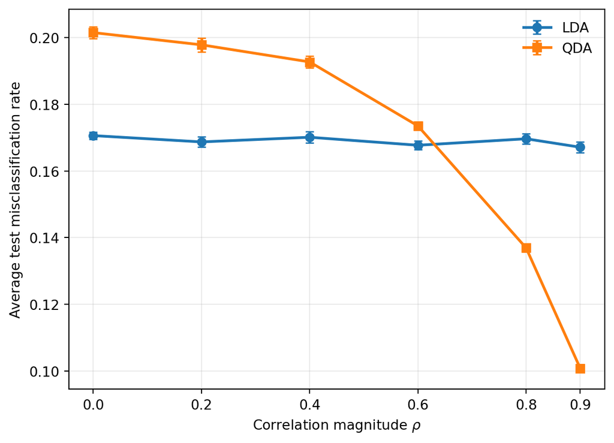

```python
rng = np.random.default_rng(SEED + 1)
errors = np.empty((len(rhos), 50, 2))
for i, rho in enumerate(rhos):
    for j in range(50):
        errors[i, j] = run_once(rho, rng)

mean_errors = errors.mean(axis=1)
se_errors = errors.std(axis=1, ddof=1) / np.sqrt(50)
display(pd.DataFrame(
    np.column_stack([mean_errors, se_errors]), index=rhos,
    columns=["LDA mean", "QDA mean", "LDA SE", "QDA SE"]
).rename_axis("rho"))

for method, col, marker in [("LDA", 0, "o"), ("QDA", 1, "s")]:
    plt.errorbar(rhos, mean_errors[:, col], yerr=se_errors[:, col],
                 label=method, marker=marker, capsize=3, linewidth=2)
plt.xlabel(r"Correlation magnitude $\rho$")
plt.ylabel("Average test misclassification rate")
plt.xticks(rhos)
plt.grid(alpha=.25)
plt.legend(frameon=False)
plt.show()
```

### (c) Interpretation

At $\rho=0$, both classes truly share the identity covariance, so LDA’s shared covariance assumption is correct. LDA averages information across classes and estimates many fewer covariance parameters, giving mean error 0.1706 versus 0.2015 for QDA. For small $\rho$, QDA’s flexibility still costs more variance than it removes bias.

As $\rho$ grows, the two class covariance matrices differ in an increasingly important way: the sign of the $X_1$–$X_2$ correlation reverses. LDA cannot represent the resulting curved decision boundary, so its error remains near 0.17. QDA can represent it, and its mean error falls to 0.1008 at $\rho=0.9$; it overtakes LDA between $\rho=0.6$ and $0.8$. This is the bias–variance trade-off: QDA pays estimation variance but gains enough bias reduction when the true covariances are substantially unequal.

The eight noise covariates have no population discrimination, yet both methods must estimate their means and covariance entries from finite samples. Those random estimates add variance and can create spurious separation. QDA is affected more because it estimates a separate full covariance matrix in each class.

## Question 4: Create and use an LDA/QDA analysis skill

### (a) Skill definition

I created `lda-qda-report-skill/SKILL.md`. Its size is **2,462 bytes**, below the 5,000-byte limit. It is stored with the homework rather than in an automatically loaded skill directory, so it is available only when I explicitly supply its path and invoke `$lda-qda-report`.

### (b) Skill application: one-page report

The exact invocation prompt was:

> Use `$lda-qda-report` from `lda-qda-report-skill/SKILL.md` to analyze `data/saheart.csv`. Predict `chd` from the other nine variables, code `famhist` as Absent=1 and Present=2, seek the best predictive performance among allowed LDA/QDA methods, use misclassification rate, and report seed 43207. Reserve a stratified test set before model selection.

#### SAheart LDA/QDA analysis

I reserved a stratified 25% test set before modeling (seed 43207): 346 training cases (226 class 0, 120 class 1) and 116 test cases. I compared ordinary LDA and QDA, shrinkage LDA, regularized QDA, and standardized PCA (2, 4, 6, or 8 components) followed by LDA/QDA. All candidates used the same five stratified, shuffled folds; scaling and PCA were re-estimated inside each fold. I selected the smallest mean cross-validation error.

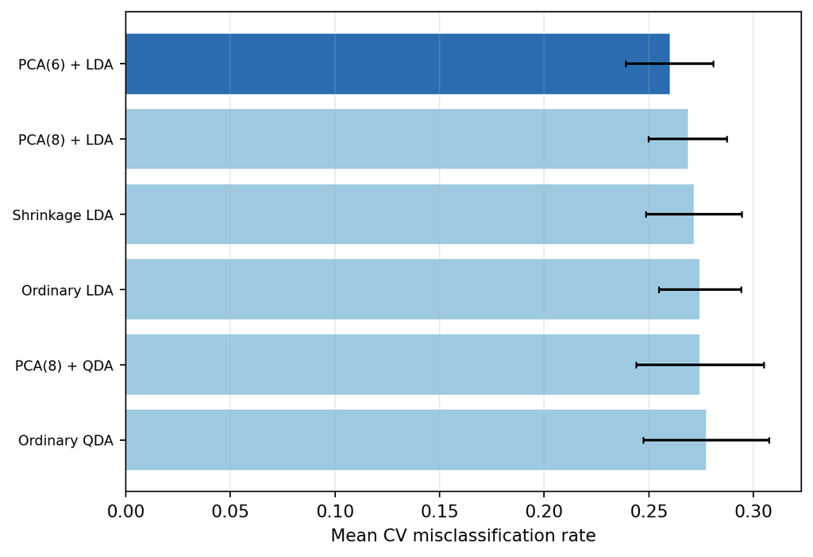

Six leading candidates; bars show mean five-fold CV error ±1 standard error across folds.

| Candidate | CV error | Fold SD | Selected | Test error |
| --- | --- | --- | --- | --- |
| PCA(6) + LDA | 0.260 | 0.047 | yes | 0.267 |
| PCA(8) + LDA | 0.269 | 0.042 |  |  |
| Shrinkage LDA | 0.271 | 0.051 |  |  |
| Ordinary LDA | 0.274 | 0.044 |  |  |
| PCA(8) + QDA | 0.274 | 0.069 |  |  |
| Ordinary QDA | 0.277 | 0.067 |  |  |

|  | predicted 0 | predicted 1 |
| --- | --- | --- |
| observed 0 | 65 | 11 |
| observed 1 | 20 | 20 |

```
Selected: PCA(6) + LDA; test error = 0.267 (31/116)
```

PCA(6)+LDA had the lowest mean CV error (0.260). Refit on all training cases, its one-time test error was **0.267** (31/116); it correctly classified 65/76 class-0 and 20/40 class-1 cases. Removing three standardized directions may reduce noise, but candidate differences are small relative to fold variation. The small, imbalanced sample and single holdout split make the test estimate uncertain, and class-1 sensitivity is only 0.50. No fitting warnings occurred.

### (c) Review and complete skill contents

I reviewed the report using only the training/CV results before the single test evaluation. The skill needed no post-test revision. Its complete contents are:

```
lda-qda-report-skill/SKILL.md
```

```markdown
---
name: lda-qda-report
description: Compare LDA/QDA classifiers and produce a concise validated statistical report. Invoke only when the user explicitly supplies this file or names this skill.
---

# LDA/QDA Analysis Report

Analyze the supplied dataset, response, predictors, coding rules, and error metric. Keep every classifier based on LDA, QDA, or a probability blend of them. Do not use the eventual test set to choose models or revise the analysis.

## Analysis protocol

1. Validate response levels, missingness, sample sizes, predictor types, and class counts. Use a stratified split to reserve a test set before model comparison; record the seed and split sizes.
2. Compare ordinary LDA and ordinary QDA. Add only defensible candidates, such as regularized/shrinkage versions, PCA followed by LDA/QDA, or convex blends of LDA/QDA class probabilities.
3. Compare candidates with the same stratified cross-validation folds and the requested error metric. Estimate every data-dependent operation (imputation, scaling, feature selection, PCA, model fitting, or blend weights) using only the analysis portion of each fold. State folds, repetitions if any, and selection rule.
4. Select the candidate with the smallest mean cross-validation error, breaking near-ties in favor of the simpler or more stable model. Refit its entire pipeline on all training observations, then evaluate it exactly once on the reserved test set.
5. Check numerical warnings, covariance rank/conditioning, class-specific errors, and sensitivity to the split or folds when feasible. Do not hide failures or unstable estimates.

## Required deliverable

Produce a clearly readable analysis report of at most one printed page. It must contain:

- a brief data/split description and candidate-model summary;
- one compact figure showing cross-validation performance with uncertainty;
- one compact table reporting the leading candidates' mean cross-validation errors, the selected model, and final test results;
- numerical model-fitting results, including the seed, fold design, selected settings, test misclassification rate, and test confusion matrix; and
- a short interpretation of the main findings and limitations.

Use honest labels, consistent decimal precision, observed classes in confusion-matrix rows, and predicted classes in columns. Keep code outside the one-page narrative unless requested. Return reproducible code and note any software warnings after the report.
```